# Homework 4

DATASCI 506

```r
library(broom)
library(infer)
library(knitr)
library(scales)
library(slider)
library(tidyverse)

theme_set(
  theme_minimal(base_size = 12) +
    theme(
      plot.title.position = "plot",
      plot.caption.position = "plot",
      panel.grid.minor = element_blank(),
      legend.position = "bottom"
    )
)
```

# Problem 1: Tidyverse — New Zealand

The `nzge` data were supplied as an RDS file because the original `nzelect` package has been archived. Candidate and Party votes are kept separate in all calculations.

```r
nzge <- readRDS("data/nzge.rds") |>
  as_tibble()

glimpse(nzge)
```

```
Rows: 728,602
Columns: 9
$ approx_location   <chr> "Albury", "Arowhenua", "Burke Pass", "Cannington", "…
$ voting_place      <chr> "School", "Maori School, Huirapa Street", "Alpine Ca…
$ party             <chr> "ACT New Zealand", "ACT New Zealand", "ACT New Zeala…
$ votes             <dbl> 16, 4, 13, 6, 1, 16, 6, 17, 48, 14, 32, 47, 8, 7, 11…
$ electorate        <chr> "Aoraki", "Aoraki", "Aoraki", "Aoraki", "Aoraki", "A…
$ voting_type       <chr> "Party", "Party", "Party", "Party", "Party", "Party"…
$ candidate         <chr> NA, NA, NA, NA, NA, NA, NA, NA, NA, NA, NA, NA, NA, …
$ election_year     <dbl> 2002, 2002, 2002, 2002, 2002, 2002, 2002, 2002, 2002…
$ electorate_number <dbl> 1, 1, 1, 1, 1, 1, 1, 1, 1, 1, 1, 1, 1, 1, 1, 1, 1, 1…
```

## 1(a) Vote count by year and vote type

```r
votes_by_year_type <- nzge |>
  summarise(
    vote_count = sum(votes, na.rm = TRUE),
    .by = c(election_year, voting_type)
  ) |>
  arrange(desc(vote_count))

votes_by_year_type |>
  mutate(vote_count = comma(vote_count)) |>
  kable(
    col.names = c("Election year", "Vote type", "Vote count"),
    caption = "New Zealand votes by election year and vote type"
  )
```

New Zealand votes by election year and vote type

| Election year | Vote type | Vote count |
| --- | --- | --- |
| 2014 | Party | 2,416,479 |
| 2014 | Candidate | 2,375,493 |
| 2008 | Party | 2,356,536 |
| 2008 | Candidate | 2,325,598 |
| 2005 | Party | 2,286,190 |
| 2005 | Candidate | 2,260,670 |
| 2011 | Party | 2,257,336 |
| 2011 | Candidate | 2,225,766 |
| 2002 | Party | 2,040,248 |
| 2002 | Candidate | 2,022,115 |

The largest total is the 2014 Party vote with 2,416,479 votes. In every election year, the Party-vote total is slightly larger than the Candidate-vote total.

## 1(b) Party shares of the 2014 Candidate vote

```r
candidate_2014 <- nzge |>
  filter(
    election_year == 2014,
    voting_type == "Candidate"
  ) |>
  summarise(
    votes = sum(votes, na.rm = TRUE),
    .by = party
  ) |>
  mutate(proportion = votes / sum(votes)) |>
  arrange(desc(proportion))

candidate_2014 |>
  mutate(
    votes = comma(votes),
    proportion = percent(proportion, accuracy = 0.01)
  ) |>
  kable(
    col.names = c("Party/category", "Votes", "Share of Candidate vote"),
    caption = "2014 Candidate-vote shares"
  )
```

2014 Candidate-vote shares

| Party/category | Votes | Share of Candidate vote |
| --- | --- | --- |
| National Party | 1,081,787 | 45.54% |
| Labour Party | 801,287 | 33.73% |
| Green Party | 165,718 | 6.98% |
| Conservative Party | 81,075 | 3.41% |
| New Zealand First Party | 73,384 | 3.09% |
| Maori Party | 42,108 | 1.77% |
| MANA Movement | 32,333 | 1.36% |
| Informal Candidate Votes | 27,886 | 1.17% |
| ACT New Zealand | 27,778 | 1.17% |
| United Future | 14,722 | 0.62% |
| Aotearoa Legalise Cannabis Party | 4,936 | 0.21% |
| Internet Party | 4,848 | 0.20% |
| Democrats for Social Credit | 4,647 | 0.20% |
| Ban1080 | 4,448 | 0.19% |
| Independent | 3,864 | 0.16% |
| NZ Independent Coalition | 1,929 | 0.08% |
| Focus New Zealand | 1,797 | 0.08% |
| Money Free Party | 391 | 0.02% |
| Communist League | 135 | 0.01% |
| Climate Party | 116 | 0.00% |
| Human Rights Party | 76 | 0.00% |
| The Expats | 70 | 0.00% |
| Alliance | 59 | 0.00% |
| NZ Economic Euthenics Party | 51 | 0.00% |
| Patriotic Revolutionary Front | 48 | 0.00% |

The National Party received the largest share of the 2014 Candidate vote: 45.5%. Labour was second with 33.7%. The source data place informal candidate ballots in the `party` field, so that category is shown explicitly and remains in the denominator.

## 1(c) Winning party by year and vote type

```r
winning_parties <- nzge |>
  summarise(
    votes = sum(votes, na.rm = TRUE),
    .by = c(election_year, voting_type, party)
  ) |>
  slice_max(
    order_by = votes,
    n = 1,
    with_ties = TRUE,
    by = c(election_year, voting_type)
  ) |>
  select(election_year, voting_type, party) |>
  pivot_wider(
    names_from = voting_type,
    values_from = party,
    names_glue = "{voting_type}_vote_winner"
  ) |>
  arrange(election_year)

winning_parties |>
  kable(
    col.names = c("Election year", "Candidate-vote winner",
                  "Party-vote winner"),
    caption = "Winning party for each vote type"
  )
```

Winning party for each vote type

[output not shown]

# Problem 2: Tidyverse — Tennis

The 2019 ATP match data come from the assigned [Tennis Abstract repository](https://github.com/azhou5849/tennis-atp-sackmann-data/tree/master). Each row is one match; the file contains separate winner and loser columns.

```r
matches <- read_csv(
  "data/atp_matches_2019.csv",
  show_col_types = FALSE
)

matches |>
  select(
    tourney_id, tourney_name, tourney_date, round,
    winner_name, loser_name, w_ace, l_ace
  ) |>
  slice_head(n = 8)
```

```
# A tibble: 8 × 8
  tourney_id tourney_name tourney_date round winner_name  loser_name w_ace l_ace
  <chr>      <chr>               <dbl> <chr> <chr>        <chr>      <dbl> <dbl>
1 2019-M020  Brisbane         20181231 F     Kei Nishiko… Daniil Me…     3     8
2 2019-M020  Brisbane         20181231 SF    Daniil Medv… Jo-Wilfri…    10    17
3 2019-M020  Brisbane         20181231 SF    Kei Nishiko… Jeremy Ch…     2    10
4 2019-M020  Brisbane         20181231 QF    Jo-Wilfried… Alex De M…    12     1
5 2019-M020  Brisbane         20181231 QF    Daniil Medv… Milos Rao…    12    29
6 2019-M020  Brisbane         20181231 QF    Jeremy Char… Yasutaka …    10    12
7 2019-M020  Brisbane         20181231 QF    Kei Nishiko… Grigor Di…     5     8
8 2019-M020  Brisbane         20181231 R16   Jo-Wilfried… Taro Dani…    11     3
```

## 2(a) Number of tournaments

```r
tournament_count <- matches |>
  summarise(tournaments = n_distinct(tourney_id))

tournament_count |>
  kable(caption = "Number of distinct tournament/event IDs in 2019")
```

Number of distinct tournament/event IDs in 2019

| tournaments |
| --- |
| 128 |

There are 128 distinct tournament/event IDs in the file. This count includes Davis Cup ties, which each have their own event ID in the source data.

## 2(b) Players winning multiple tournaments

A tournament champion is identified as the winner of a match whose round is coded `F` (final).

```r
tournament_titles <- matches |>
  filter(round == "F") |>
  count(winner_name, name = "tournaments_won", sort = TRUE)

multiple_title_winners <- tournament_titles |>
  filter(tournaments_won > 1)

multiple_title_winners |>
  kable(
    col.names = c("Player", "Tournaments won"),
    caption = "Players who won more than one tournament"
  )
```

Players who won more than one tournament

| Player | Tournaments won |
| --- | --- |
| Dominic Thiem | 5 |
| Novak Djokovic | 5 |
| Daniil Medvedev | 4 |
| Rafael Nadal | 4 |
| Roger Federer | 4 |
| Alex De Minaur | 3 |
| Stefanos Tsitsipas | 3 |
| Benoit Paire | 2 |
| Cristian Garin | 2 |
| Jo-Wilfried Tsonga | 2 |
| Matteo Berrettini | 2 |
| Nick Kyrgios | 2 |

Yes. 12 players won more than one tournament. The maximum was 5 titles, shared by Dominic Thiem and Novak Djokovic.

## 2(c) Do winners have more aces?

Because both ace totals come from the same match, I analyze the within-match difference, winner aces minus loser aces. Matches missing either ace count are excluded.

```r
ace_differences <- matches |>
  filter(!is.na(w_ace), !is.na(l_ace)) |>
  transmute(ace_difference = w_ace - l_ace)

ace_summary <- ace_differences |>
  summarise(
    matches = n(),
    mean_difference = mean(ace_difference),
    median_difference = median(ace_difference),
    winner_had_more = mean(ace_difference > 0)
  )

ace_summary |>
  mutate(winner_had_more = percent(winner_had_more, accuracy = 0.1)) |>
  kable(
    digits = 2,
    col.names = c("Complete matches", "Mean difference",
                  "Median difference", "Winner had more aces"),
    caption = "Within-match ace comparison"
  )
```

Within-match ace comparison

| Complete matches | Mean difference | Median difference | Winner had more aces |
| --- | --- | --- | --- |
| 2694 | 1.7 | 1 | 57.3% |

I use a one-sided, simulation-based test from the `infer` package. The null hypothesis is that the population mean difference is zero, against the alternative that it is positive. This keeps the inferential workflow in the tidyverse rather than calling a base-R hypothesis-test function.

```r
set.seed(506)

observed_ace_mean <- ace_differences |>
  specify(response = ace_difference) |>
  calculate(stat = "mean")

null_ace_distribution <- ace_differences |>
  specify(response = ace_difference) |>
  hypothesize(null = "point", mu = 0) |>
  generate(reps = 9999, type = "bootstrap") |>
  calculate(stat = "mean")

ace_test <- null_ace_distribution |>
  summarise(
    p_value =
      (sum(stat >= observed_ace_mean$stat) + 1) / (n() + 1)
  )

tibble(
  observed_mean_difference = observed_ace_mean$stat,
  simulation_p_value = ace_test$p_value
) |>
  kable(
    digits = 4,
    col.names = c("Observed mean difference", "One-sided p-value"),
    caption = "Simulation-based test of winner-minus-loser aces"
  )
```

Simulation-based test of winner-minus-loser aces

| Observed mean difference | One-sided p-value |
| --- | --- |
| 1.7049 | 1e-04 |

Winners averaged 1.7 more aces per match. The one-sided simulation p-value is <0.001. This is strong evidence that winners have more aces than losers on average. This is an association within completed matches; it does not establish that aces alone cause a player to win.

## 2(d) Highest win rate, minimum five matches

I reshape winners and losers into a common player column, mark each outcome, and then calculate wins divided by total matches.

```r
player_records <- bind_rows(
  matches |>
    transmute(player = winner_name, won = 1L),
  matches |>
    transmute(player = loser_name, won = 0L)
) |>
  summarise(
    matches = n(),
    wins = sum(won),
    losses = matches - wins,
    win_rate = mean(won),
    .by = player
  ) |>
  filter(matches >= 5) |>
  arrange(desc(win_rate), desc(matches))

highest_win_rate <- player_records |>
  slice_max(win_rate, n = 1, with_ties = TRUE)

highest_win_rate |>
  mutate(win_rate = percent(win_rate, accuracy = 0.1)) |>
  kable(
    col.names = c("Player", "Matches", "Wins", "Losses", "Win rate"),
    caption = "Highest 2019 win rate among players with at least five matches"
  )
```

Highest 2019 win rate among players with at least five matches

| Player | Matches | Wins | Losses | Win rate |
| --- | --- | --- | --- | --- |
| Rafael Nadal | 69 | 60 | 9 | 87.0% |

Rafael Nadal had the highest win rate: 60 wins in 69 matches, or 87.0%.

# Problem 3: Visualization — US COVID-19 cases

The data are the assigned [New York Times state-level rolling averages](https://raw.githubusercontent.com/nytimes/covid-19-data/refs/heads/master/rolling-averages/us-states.csv). The source already supplies seven-day average daily cases and rates per 100,000 population.

```r
covid <- read_csv("data/us-states.csv", show_col_types = FALSE)
```

## 3(a) Major and minor spikes

To make “spike” reproducible, I define a peak as a local maximum within a plus-or-minus 28-day window, after summing the state seven-day averages. Peaks below 25,000 cases per day are omitted as small fluctuations. A retained peak is called major when it reaches at least 150,000 daily cases and minor otherwise.

```r
national_cases <- covid |>
  summarise(
    cases_avg = sum(cases_avg, na.rm = TRUE),
    .by = date
  ) |>
  arrange(date) |>
  mutate(
    local_window_max = slide_dbl(
      cases_avg,
      max,
      .before = 28,
      .after = 28,
      .complete = TRUE
    )
  )

case_peaks <- national_cases |>
  filter(
    cases_avg == local_window_max,
    cases_avg >= 25000
  ) |>
  mutate(
    spike_type = if_else(cases_avg >= 150000, "Major", "Minor"),
    label = str_c(format(date, "%b %Y"), "\n", comma(round(cases_avg)))
  )

spike_counts <- case_peaks |>
  count(spike_type, name = "number_of_spikes")

spike_counts |>
  kable(
    col.names = c("Spike classification", "Number of spikes"),
    caption = "Detected national COVID-19 case spikes"
  )
```

Detected national COVID-19 case spikes

| Spike classification | Number of spikes |
| --- | --- |
| Major | 3 |
| Minor | 5 |

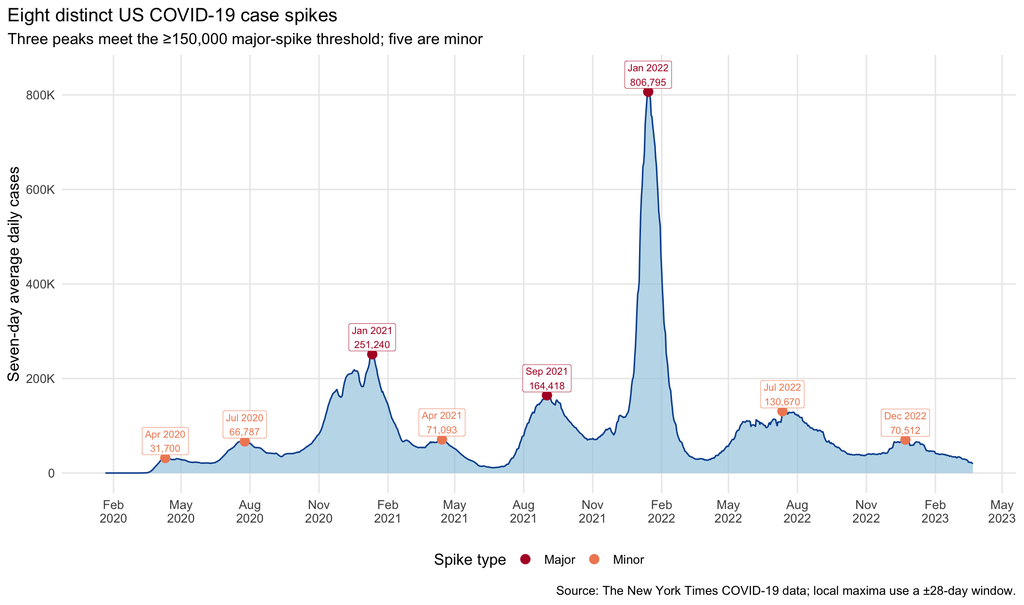

```r
ggplot(national_cases, aes(date, cases_avg)) +
  geom_area(fill = "#9ecae1", alpha = 0.65) +
  geom_line(color = "#08519c", linewidth = 0.55) +
  geom_point(
    data = case_peaks,
    aes(color = spike_type),
    size = 3
  ) +
  geom_label(
    data = case_peaks,
    aes(label = label, color = spike_type),
    size = 2.7,
    linewidth = 0.15,
    fill = "white",
    nudge_y = 36000,
    show.legend = FALSE
  ) +
  scale_color_manual(values = c(Major = "#b2182b", Minor = "#ef8a62")) +
  scale_x_date(date_breaks = "3 months", date_labels = "%b\n%Y") +
  scale_y_continuous(labels = label_number(scale_cut = cut_short_scale())) +
  coord_cartesian(clip = "off") +
  labs(
    title = "Eight distinct US COVID-19 case spikes",
    subtitle = "Three peaks meet the ≥150,000 major-spike threshold; five are minor",
    x = NULL,
    y = "Seven-day average daily cases",
    color = "Spike type",
    caption = "Source: The New York Times COVID-19 data; local maxima use a ±28-day window."
  )
```

Under this definition, there are 3 major spikes and 5 minor spikes. The January 2022 Omicron peak is visually exceptional at more than 800,000 average daily cases, over three times the next-largest peak.

## 3(b) Highest- and lowest-rate states

I restrict “states” to the 50 states plus the District of Columbia. Summing the daily `cases_avg_per_100k` values across the full period gives an approximately cumulative, population-standardized rate and permits a fair ranking across states of different sizes.

```r
states_50_dc <- c(state.name, "District of Columbia")

overall_state_rates <- covid |>
  filter(state %in% states_50_dc) |>
  summarise(
    overall_rate = sum(cases_avg_per_100k, na.rm = TRUE),
    .by = state
  ) |>
  arrange(desc(overall_rate))

extreme_states <- bind_rows(
  overall_state_rates |> slice_head(n = 1) |> mutate(rank = "Highest"),
  overall_state_rates |> slice_tail(n = 1) |> mutate(rank = "Lowest")
)

extreme_states |>
  mutate(overall_rate = comma(overall_rate, accuracy = 1)) |>
  select(rank, state, overall_rate) |>
  kable(
    col.names = c("Overall-rate rank", "State",
                  "Summed daily rate per 100,000"),
    caption = "States at the extremes of the overall population-standardized rate"
  )
```

States at the extremes of the overall population-standardized rate

| Overall-rate rank | State | Summed daily rate per 100,000 |
| --- | --- | --- |
| Highest | Rhode Island | 43,296 |
| Lowest | Maine | 22,020 |

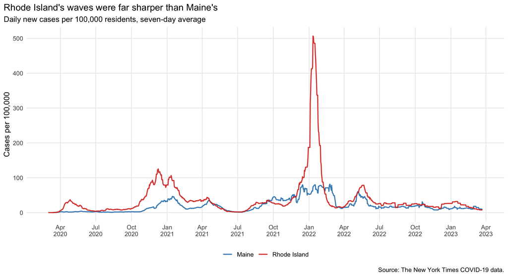

```r
extreme_trajectories <- covid |>
  filter(state %in% extreme_states$state)

ggplot(
  extreme_trajectories,
  aes(date, cases_avg_per_100k, color = state)
) +
  geom_line(linewidth = 0.8, alpha = 0.9) +
  scale_color_manual(values = c("Maine" = "#2c7fb8", "Rhode Island" = "#d7301f")) +
  scale_x_date(date_breaks = "3 months", date_labels = "%b\n%Y") +
  scale_y_continuous(labels = label_number()) +
  labs(
    title = "Rhode Island's waves were far sharper than Maine's",
    subtitle = "Daily new cases per 100,000 residents, seven-day average",
    x = NULL,
    y = "Cases per 100,000",
    color = NULL,
    caption = "Source: The New York Times COVID-19 data."
  )
```

Rhode Island has the highest overall standardized rate, while Maine has the lowest. Rhode Island experienced much larger winter surges, especially the Omicron wave, which peaked above 500 cases per 100,000 per day. Maine’s curve was lower and flatter early in the pandemic, and its recorded peak was only about 81 per 100,000. The gap is therefore driven not just by one date but by repeatedly higher and sharper Rhode Island waves.

## 3(c) First five states substantially affected

I define “substantial” as the first date a state’s seven-day average reached 5 new daily cases per 100,000. This threshold is high enough to avoid labeling isolated initial cases as sustained community spread. Territories are excluded using the same 50-state-plus-DC definition.

```r
first_substantial_dates <- covid |>
  filter(
    state %in% states_50_dc,
    cases_avg_per_100k >= 5
  ) |>
  summarise(
    first_substantial = min(date),
    .by = state
  ) |>
  arrange(first_substantial) |>
  slice_head(n = 5)

first_substantial_dates |>
  kable(
    col.names = c("State", "First date at or above 5 per 100,000"),
    caption = "First five states to cross the substantial-spread threshold"
  )
```

First five states to cross the substantial-spread threshold

| State | First date at or above 5 per 100,000 |
| --- | --- |
| New York | 2020-03-21 |
| New Jersey | 2020-03-24 |
| Louisiana | 2020-03-26 |
| Massachusetts | 2020-03-27 |
| Michigan | 2020-03-28 |

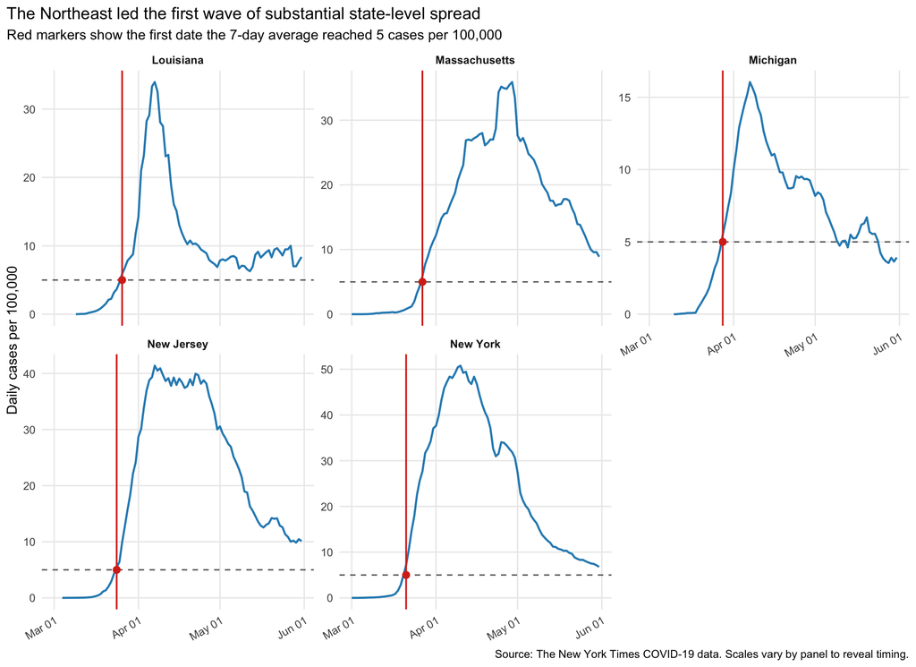

```r
early_trajectories <- covid |>
  filter(
    state %in% first_substantial_dates$state,
    between(date, as.Date("2020-03-01"), as.Date("2020-05-31"))
  )

ggplot(early_trajectories, aes(date, cases_avg_per_100k)) +
  geom_hline(yintercept = 5, color = "#636363", linetype = "dashed") +
  geom_line(color = "#2b8cbe", linewidth = 0.85) +
  geom_vline(
    data = first_substantial_dates,
    aes(xintercept = first_substantial),
    color = "#d7301f",
    linewidth = 0.7
  ) +
  geom_point(
    data = first_substantial_dates,
    aes(x = first_substantial, y = 5),
    color = "#d7301f",
    size = 2.5
  ) +
  facet_wrap(~ state, scales = "free_y") +
  scale_x_date(date_breaks = "1 month", date_labels = "%b %d") +
  labs(
    title = "The Northeast led the first wave of substantial state-level spread",
    subtitle = "Red markers show the first date the 7-day average reached 5 cases per 100,000",
    x = NULL,
    y = "Daily cases per 100,000",
    caption = "Source: The New York Times COVID-19 data. Scales vary by panel to reveal timing."
  ) +
  theme(
    strip.text = element_text(face = "bold"),
    axis.text.x = element_text(angle = 30, hjust = 1)
  )
```

The first five states were New York (March 21), New Jersey (March 24), Louisiana (March 26), Massachusetts (March 27), and Michigan (March 28). Four of the five are in the Northeast/Midwest corridor, supporting the argument that the first large US wave was geographically concentrated there, with Louisiana as the notable early Southern exception.

# Sources

- `nzge.rds`, supplied by the course at https://phuongov.github.io/stats506-f26/data_f26/nzge.rds.
- Jeff Sackmann/Tennis Abstract, [2019 ATP match data](https://github.com/azhou5849/tennis-atp-sackmann-data/tree/master).
- The New York Times, [US state COVID-19 rolling averages](https://raw.githubusercontent.com/nytimes/covid-19-data/refs/heads/master/rolling-averages/us-states.csv).